# Homework 3

PA 541

Alexis Kwan

# Part 1

Variable name (Description)

- code (School)
- county (County name)
- name (School name)
- type (School type (public or private))
- district (School district name)
- city (City location)
- enrollment (Total kindergarten enrollment)
- pbe_pct (Rounded percent of personal belief exemptions)
- exempt (Percent of students exempt from providing vaccination records)
- med_exempt (Percent exempt due to medical reasons)
- rel_exempt (Percent exempt due to religious reasons)

## Question 1

### 1a

In how many schools is the percentage of students exempt for medical reasons (med_exempt) greater than the percentage exempt for religious reasons (rel_exempt)? [2 pts] Of this set of schools, what percent are public schools? [2 pts]

```r
all_schools <- cavax %>%
  filter(med_exempt > rel_exempt) %>%
  count()
all_schools
```

| n |
| --- |
| 518 |

There are 518 schools where the percentage of medically exempt students is greater than the percentage of religiously exempt students.

```r
public_schools <- cavax %>%
  filter(med_exempt > rel_exempt & type == "PUBLIC") %>%
  count()
public_schools / all_schools
```

| n |
| --- |
| 0.8648649 |

86% of the schools are public schools.

### 1b

Which county, when averaging across all the schools in that county, has the highest average percentage of exempt students (exempt)? Note, we are using the variable exempt here. [2 pts]

```r
cavax %>%
  group_by(county) %>%
  summarise(mean_exempt = mean(exempt)) %>%
  arrange(desc(mean_exempt))
```

| county | mean_exempt |
| --- | --- |
| NEVADA | 24.0021053 |
| MARIPOSA | 16.5480000 |
| HUMBOLDT | 14.1917143 |
| DEL NORTE | 13.2400000 |
| LASSEN | 12.5309091 |
| SANTA CRUZ | 11.8054545 |
| EL DORADO | 10.5537500 |
| CALAVERAS | 9.8000000 |
| SHASTA | 9.7821429 |
| MENDOCINO | 9.3654545 |

[output cut: 47 more lines]

Nevada county seems to have the highest average percent of students exempt at 24%.

### 1c

Create a bar chart that shows for private and public schools (type) the percent of students exempt from providing vaccination records (exempt). [2 pts]

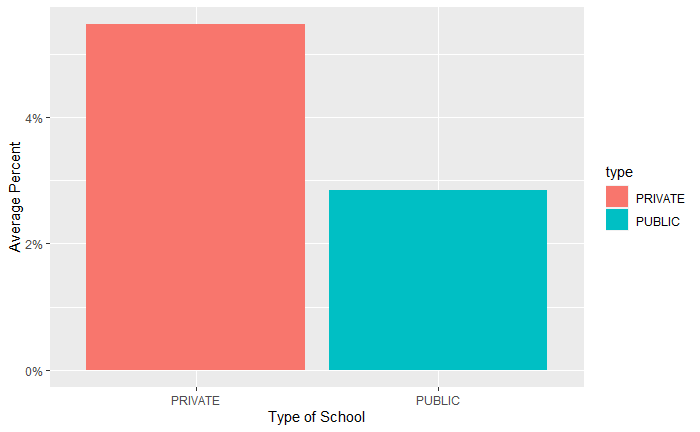

```r
cavax %>%
  group_by(type) %>%
  summarise(mean_exempt = mean(exempt)) %>%
  ggplot(aes(x = type, y = mean_exempt, fill = type)) +
  geom_col() +
  scale_y_continuous(labels = scales::percent_format(accuracy = 1, scale = 1)) +
  ylab("Average Percent") +
  xlab("Type of School")
```

## Question 2

- Estimate a model predicting exempt (exempt) by district type (type) and enrollment (enrollment). [2 pts]
- Treat exempt as a continuous variable (and thus you can use standard OLS). Interpret the intercept and the coefficients. [4 pts]
- What is the predicted exempt percentage for a public school with 100 students in kindergarten? [2 pts]
- What is the predicted exempt percentage for a private school with 80 students in kindergarten? [2pts]

```r
cavax_lm <- lm(exempt ~ type + enrollment, data = cavax)
summary(cavax_lm)
```

```
Call:
lm(formula = exempt ~ type + enrollment, data = cavax)

Residuals:
   Min     1Q Median     3Q    Max
-5.993 -3.296 -1.727  0.588 86.986

Coefficients:
             Estimate Std. Error t value Pr(>|t|)
(Intercept)  6.288602   0.209140  30.069  < 2e-16 ***
typePUBLIC  -0.860822   0.263483  -3.267  0.00109 **
enrollment  -0.029606   0.002383 -12.425  < 2e-16 ***
---
Signif. codes:  0 ‘***’ 0.001 ‘**’ 0.01 ‘*’ 0.05 ‘.’ 0.1 ‘ ’ 1

Residual standard error: 7.396 on 7029 degrees of freedom
Multiple R-squared:  0.04034,   Adjusted R-squared:  0.04007
F-statistic: 147.7 on 2 and 7029 DF,  p-value: < 2.2e-16
```

## Question 3

- Test whether the assumption of homoskedasticy has been met. [2 pts]
- Discuss results. [2 pts]
- Calculate the VIF for each variable. [2 pts]
- Should we be concerned with multicollinearity. [2 pts]
  - (Note, the vif() command is in the ‘car’ package. You can also calculate the VIF yourself as we did in class)

Testing homoskedasticy with a squared residual term:

```r
cavax$residsq <- resid(cavax_lm)**2
cavax_resid_lm <- lm(residsq ~ type + enrollment, data = cavax)
summary(cavax_resid_lm)
```

```
Call:
lm(formula = residsq ~ type + enrollment, data = cavax)

Residuals:
   Min     1Q Median     3Q    Max
-125.9  -57.9  -37.1  -17.8 7439.3

Coefficients:
            Estimate Std. Error t value Pr(>|t|)
(Intercept) 136.5528     9.1287  14.959  < 2e-16 ***
typePUBLIC  -39.2252    11.5007  -3.411 0.000652 ***
enrollment   -0.6662     0.1040  -6.406 1.59e-10 ***
---
Signif. codes:  0 ‘***’ 0.001 ‘**’ 0.01 ‘*’ 0.05 ‘.’ 0.1 ‘ ’ 1

Residual standard error: 322.8 on 7029 degrees of freedom
Multiple R-squared:  0.01512,   Adjusted R-squared:  0.01484
F-statistic: 53.95 on 2 and 7029 DF,  p-value: < 2.2e-16
```

Testing multicollinearity with VIF:

```r
vif(cavax_lm)
```

```
      type enrollment
  1.413965   1.413965
```

```r
sqrt(vif(cavax_lm))
```

```
      type enrollment
  1.189103   1.189103
```

We see that with the square root of the VIF, about $\sqrt{1.41}\approx1.19$ for each variable, that there is a slight inflation of standard errors due to multicollinearity. Multicollinearity does not seem to be issue since the square root of the VIF value is relatively small.

## Question 4

- Recenter the variable enrollment at its mean. [2 pts]
- Create an interaction between type (type) and student enrollment (enrollment) recentered and rerun the model predicting exempt (exempt). [2 pts]
- Assume that type moderates the effect of enrollment in your interpretation of the interaction.
  - 1. Interpret the results on each coefficient.
  - 2. Create a plot to visualize the interaction. [4 pts]

```r
cavax$enrollment_ctr <- cavax$enrollment - mean(cavax$enrollment)
cavax_lm4 <- lm(exempt ~ type + enrollment_ctr + type*enrollment_ctr, data = cavax)
summary(cavax_lm4)
```

```
Call:
lm(formula = exempt ~ type + enrollment_ctr + type * enrollment_ctr,
    data = cavax)

Residuals:
   Min     1Q Median     3Q    Max
-6.070 -3.293 -1.726  0.587 86.926

Coefficients:
                           Estimate Std. Error t value Pr(>|t|)
(Intercept)                3.837202   0.600435   6.391 1.76e-10 ***
typePUBLIC                -0.651213   0.609131  -1.069  0.28507
enrollment_ctr            -0.034017   0.011800  -2.883  0.00395 **
typePUBLIC:enrollment_ctr  0.004599   0.012048   0.382  0.70272
---
Signif. codes:  0 ‘***’ 0.001 ‘**’ 0.01 ‘*’ 0.05 ‘.’ 0.1 ‘ ’ 1

Residual standard error: 7.396 on 7028 degrees of freedom
Multiple R-squared:  0.04036,   Adjusted R-squared:  0.03995
F-statistic: 98.53 on 3 and 7028 DF,  p-value: < 2.2e-16
```

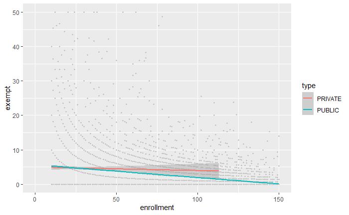

```r
cavax %>%
  ggplot(aes(x = enrollment, y = exempt, color = type)) + geom_point(size = 0.75, color = "grey") + geom_smooth(method = "lm") + xlim(0,150) + ylim(0,50)
```

## Question 5

- Let’s log transform (using the natural log) the variable enrollment and call the new variable log_enroll. [2pts]
- Estimate a model predicting exempt (exempt) by district type (type) and log of enrollment (log_enrollment). [ 2pts]
- Interpret the coefficient on the log of enrollment. [2 pts]
- Does it make more sense to use enrollment or the log of enrollment as the predictor variable? Why? [4 pts]

```r
cavax$log_enrollment <- log(cavax$enrollment)
cavax_lm5 <- lm(exempt ~ type + log_enrollment, data = cavax)
summary(cavax_lm5)
```

```
Call:
lm(formula = exempt ~ type + log_enrollment, data = cavax)

Residuals:
   Min     1Q Median     3Q    Max
-8.417 -2.982 -1.461  0.867 85.934

Coefficients:
               Estimate Std. Error t value Pr(>|t|)
(Intercept)     14.1408     0.5410  26.137   <2e-16 ***
typePUBLIC       0.5707     0.2878   1.983   0.0474 *
log_enrollment  -2.7338     0.1589 -17.201   <2e-16 ***
---
Signif. codes:  0 ‘***’ 0.001 ‘**’ 0.01 ‘*’ 0.05 ‘.’ 0.1 ‘ ’ 1

Residual standard error: 7.324 on 7029 degrees of freedom
Multiple R-squared:  0.05888,   Adjusted R-squared:  0.05861
F-statistic: 219.9 on 2 and 7029 DF,  p-value: < 2.2e-16
```

When a school is private and there is no enrollment, there is on average an exemption rate of 14%. Public schools differ from private schools by about 0.57% in exemptions of students. Every one percent increase in enrollment results in a 0.027 unit decrease in exemptions. All of the coefficients are statistically significant at significance levels of 0.05 and lower. Log of enrollment seems to make more sense since the shape of the distribution looks more exponential-like and the R-square value increased for this model compared to the non-log model, while still maintaining statistical significance.

## Question 6

- Create a binary variable to indicate high versus low exempt rates. For schools with exempt percentages equal to or greater than 33 percent, indicate them as “high”, for all other schools indicate them as “low”. [2 pts]
- Run a logistic regression predicting whether a school is high versus low, in other words, we want our model to predict schools falling into the high category. In your model use the predictors of school type (type) and enrollment (enrollment) (note: do not use log_enroll in this model). [2 pts]
- Interpret the coefficients on type and enrollment in terms of both log odds and odds. [ 6 pts]
- What is the probability of being a high exempt school if the school is private and has 100 students enrolled? [2 pts]

```r
cavax$binary_exempt <- ifelse(cavax$exempt >= 33, 1, 0)
head(cavax$binary_exempt)
```

```
[1] 0 0 0 0 0 0
```

```r
cavax_glm <- glm(binary_exempt ~ type + enrollment, family=binomial(link="logit"), data = cavax)
summary(cavax_glm)
```

```
Call:
glm(formula = binary_exempt ~ type + enrollment, family = binomial(link = "logit"),
    data = cavax)

Deviance Residuals:
    Min       1Q   Median       3Q      Max
-0.3496  -0.2117  -0.1293  -0.0801   4.5249

Coefficients:
             Estimate Std. Error z value Pr(>|z|)
(Intercept) -2.569319   0.174010 -14.765  < 2e-16 ***
typePUBLIC   0.115309   0.232708   0.496     0.62
enrollment  -0.031009   0.004197  -7.388 1.49e-13 ***
---
Signif. codes:  0 ‘***’ 0.001 ‘**’ 0.01 ‘*’ 0.05 ‘.’ 0.1 ‘ ’ 1

(Dispersion parameter for binomial family taken to be 1)

    Null deviance: 1108.0  on 7031  degrees of freedom
Residual deviance: 1005.3  on 7029  degrees of freedom
AIC: 1011.3

Number of Fisher Scoring iterations: 8
```

```r
exp(coef(cavax_glm))
```

```
(Intercept)  typePUBLIC  enrollment
 0.07658769  1.12222035  0.96946696
```

```r
# school is private and has 100 students
s1=as.matrix(c(1,0,100))
# probability
1/(1+exp(-crossprod(s1, coef(cavax_glm))))
```

```
            [,1]
[1,] 0.003435308
```

The probability that a private school with 100 students has a high percentage of exemptions is about 0.3%.

# Part 2

## Question 7

Variable name (Description)

- stateid (State id)
- statename (Name of state)
- shall (Equals 1 if state has concealed carry on that year and 0 if not)
- year (Year)
- vio (Violent crime rate per 100,000 people )
- mur (Murder rate per 100,000 people )

### 7a

Let’s begin by exploring the data. How many years are there in concealed_carry data? How many observations per state? [2 pts]

```r
concealed_carry <- read.csv("concealed_carry.csv")
length(unique(concealed_carry$year))
```

```
[1] 23
```

23 different years are represented in the concealed_carry data set.

```r
concealed_carry %>%
  group_by(statename) %>%
  count()
```

| statename | n |
| --- | --- |
| Alabama | 23 |
| Alaska | 23 |
| Arizona | 23 |
| Arkansas | 23 |
| California | 23 |
| Colorado | 23 |
| Connecticut | 23 |
| Delaware | 23 |
| District of Columbia | 23 |
| Florida | 23 |

[output cut: 41 more lines]

Each state also has 23 observations, one for each year.

### 7b

How many states had concealed carry laws (shall) in 1977 and how many had concealed carry laws in 1999? [ 4pts]

```r
concealed_carry %>%
  filter(shall == 1 & year == 1977) %>%
  nrow()
```

```
[1] 4
```

```r
concealed_carry %>%
  filter(shall == 1 & year == 1999) %>%
  nrow()
```

```
[1] 29
```

4 states in 1977 and 29 in 1999.

### 7c

Create a plot tracking the violent crime rate (vio) over time for states that have ever adopted conceal carry laws (shall) and those that have never adopted the law. [4 pts]

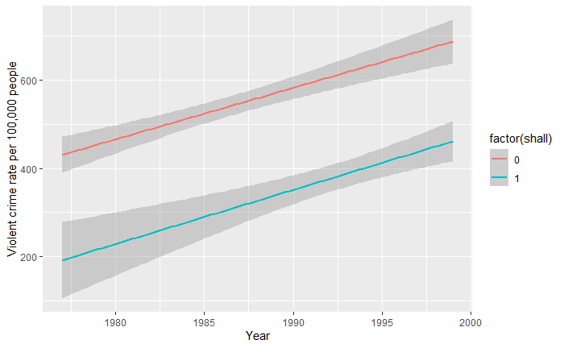

```r
ggplot(data=concealed_carry, aes(x = year, y = vio, color = factor(shall))) +
  geom_smooth(method = "lm") +
  xlab("Year") +
  ylab("Violent crime rate per 100,000 people")
```

## Question 8

- Convert the violent crime rate (vio) into a logged variable (using the natural log), call it log_vio. [2 pts]
- This will be our dependent variable. Run a pooled regression of the data (i.e., standard OLS model as if this was cross-sectional data) predicting the log of violent crimes (log_vio) as a function of the presence of concealed carry laws (shall) and a set of dummy variables for year. [2 pts]
- Interpret the effect of shall. [2 pts]
- In general terms, what do the year dummy variables tell us about crime trends? [2 pts]
- In our current specification of the model, is the effect of shall the same for all years? Why or why not? [2 pts]

```r
concealed_carry$log_vio <- log(concealed_carry$vio)
concealed_carry$year <- as.factor(concealed_carry$year)
concealed_lm <- lm(log_vio ~ shall + year, data = concealed_carry)
summary(concealed_lm)
```

```
Call:
lm(formula = log_vio ~ shall + year, data = concealed_carry)

Residuals:
     Min       1Q   Median       3Q      Max
-2.14538 -0.43698  0.05355  0.40556  1.68492

Coefficients:
            Estimate Std. Error t value Pr(>|t|)
(Intercept)  5.86727    0.08372  70.086  < 2e-16 ***
shall       -0.59812    0.04446 -13.452  < 2e-16 ***
year1978     0.04838    0.11829   0.409 0.682589
year1979     0.14372    0.11829   1.215 0.224631
year1980     0.18781    0.11829   1.588 0.112634
year1981     0.17746    0.11829   1.500 0.133838
year1982     0.14767    0.11829   1.248 0.212166
year1983     0.08999    0.11829   0.761 0.446945
year1984     0.10077    0.11829   0.852 0.394470
year1985     0.12826    0.11829   1.084 0.278473
year1986     0.20558    0.11832   1.738 0.082559 .
year1987     0.19364    0.11834   1.636 0.102056
year1988     0.24561    0.11837   2.075 0.038211 *
year1989     0.28168    0.11837   2.380 0.017490 *
year1990     0.41694    0.11849   3.519 0.000451 ***
year1991     0.48647    0.11868   4.099 4.44e-05 ***
year1992     0.52834    0.11883   4.446 9.59e-06 ***
year1993     0.53923    0.11883   4.538 6.28e-06 ***
year1994     0.51493    0.11883   4.333 1.60e-05 ***
year1995     0.54706    0.11921   4.589 4.94e-06 ***
year1996     0.54408    0.11983   4.540 6.21e-06 ***
year1997     0.55553    0.12028   4.619 4.30e-06 ***
year1998     0.49975    0.12028   4.155 3.50e-05 ***
year1999     0.44010    0.12028   3.659 0.000265 ***
---
Signif. codes:  0 ‘***’ 0.001 ‘**’ 0.01 ‘*’ 0.05 ‘.’ 0.1 ‘ ’ 1

Residual standard error: 0.5973 on 1149 degrees of freedom
Multiple R-squared:  0.161, Adjusted R-squared:  0.1442
F-statistic: 9.585 on 23 and 1149 DF,  p-value: < 2.2e-16
```